# Case Study 2: How Can a Wellness Technology Company Play It Smart?

Abdullahi Ali

`Fitbit Dataset`

## Summary

Bellabeat is a women’s wellness brand with an ecosystem of products and services centered on women’s health. In order to provide women better insight into how their bodies function and to empower them to make healthier decisions, the firm creates wearables and complementary devices that track biometric and lifestyle data.

They provide a variety of smart gadgets that may record menstrual cycles and reproductive health as well as data on activity, sleep, stress, heart rate, cardiac coherence, and respiration rate.

Bellabeat promises to calculate wellness and readiness scores, highlight self-care deficiencies, and recommend adjustments using the accompanying app.

This case primarily focuses on analyzing data from a competing product (a Fitbit tracker, to see how it might help to open up new growth potential for the company.

## 1. 0 Ask

### 1. 1 Business Task Statment

Analyze patterns and relationships in how consumers utilize non-Bellabeat smart devices to measure their daily activity, calorie expenditure, and sleep quality, with the goal of applying results to Bellabeat’s product development and marketing strategy.

### 1.2 Stakeholders

- Urška Sršen - Bellabeat cofounder and Chief Creative Officer
- Sando Mur - Bellabeat cofounder and key member of Bellabeat executive team
- Bellabeat Marketing Analytics team

The analysis will help Bellabeat team to design more innovative and competitive smart wellness devices that meet the needs and preferences of their target market. The analysis will also help the Bellabeat Marketing Analytics team to create more effective and engaging campaigns that showcase the benefits and features of Bellabeat’s products and app.”

### 1. 3 Product

#### - Bellabeat app:

In this instance, our attention will be on the Bellabeat app, which offers users health information on their exercise, sleep, stress, menstrual cycle, and mindfulness practices. Users may use this information to better understand their routines and choose healthy options. Their collection of smart wellness devices are connected to the Bellabeat app.

## 2. 0 Prepare phase

## 2. 1 Information about our Data

I looked through the CSV tables in Google Sheets because the sample size was so small. I was able to confirm the characteristics, findings, and relationships between each table. Each table’s sample size (users) was counted, and the analysis’s 31-day duration was confirmed.

### 2. 2 Data Limitation

The following details about the users and their context are unknown:

- Age
- Gender-identity
- Location

### 2. 3 Expected outcomes

- Higher Daily Activity is Associated with Calories Burned
- Increased sleep duration is correlated with higher calorie expenditure.

### 2.4 Questions

1. How is the app’s use assisting users in being healthier?
2. Is “More Sleep” related with a high calorie expenditure or a low calorie expenditure?

## 3. 0 Process Data

### 3. 1 Installing and loading packages

```r
library(janitor)
library(dplyr)
```

```r
library(skimr)
library(ggplot2)
install.packages("waffle")
installed.packages("plotrix")
```

```
##      Package LibPath Version Priority Depends Imports LinkingTo Suggests
##      Enhances License License_is_FOSS License_restricts_use OS_type Archs
##      MD5sum NeedsCompilation Built
```

```r
library(waffle)
```

### 3. 2 import Data

```r
dailyActivity_merged <- read.csv("~/Desktop/Case Study /dailyActivity_merged.csv")
 View(dailyActivity_merged)

 Sleep_Calories...Sheet1 <- read.csv("~/Desktop/Case Study /Sleep_Calories - Sheet1.csv")
   View(Sleep_Calories...Sheet1)
```

### 3. 3 Dataset previews

```r
skim_without_charts(dailyActivity_merged)
```

Data summary

| Name | dailyActivity_merged |
| --- | --- |
| Number of rows | 940 |
| Number of columns | 15 |
| _______________________ |  |
| Column type frequency: |  |
| character | 1 |
| numeric | 14 |
| ________________________ |  |
| Group variables | None |

**Variable type: character**

| skim_variable | n_missing | complete_rate | min | max | empty | n_unique | whitespace |
| --- | --- | --- | --- | --- | --- | --- | --- |
| ActivityDate | 0 | 1 | 8 | 9 | 0 | 31 | 0 |

**Variable type: numeric**

| skim_variable | n_missing | complete_rate | mean | sd | p0 | p25 | p50 | p75 | p100 |
| --- | --- | --- | --- | --- | --- | --- | --- | --- | --- |
| Id | 0 | 1 | 4.855407e+09 | 2.424805e+09 | 1503960366 | 2.320127e+09 | 4.445115e+09 | 6.962181e+09 | 8.877689e+09 |
| TotalSteps | 0 | 1 | 7.637910e+03 | 5.087150e+03 | 0 | 3.789750e+03 | 7.405500e+03 | 1.072700e+04 | 3.601900e+04 |
| TotalDistance | 0 | 1 | 5.490000e+00 | 3.920000e+00 | 0 | 2.620000e+00 | 5.240000e+00 | 7.710000e+00 | 2.803000e+01 |
| TrackerDistance | 0 | 1 | 5.480000e+00 | 3.910000e+00 | 0 | 2.620000e+00 | 5.240000e+00 | 7.710000e+00 | 2.803000e+01 |
| LoggedActivitiesDistance | 0 | 1 | 1.100000e-01 | 6.200000e-01 | 0 | 0.000000e+00 | 0.000000e+00 | 0.000000e+00 | 4.940000e+00 |
| VeryActiveDistance | 0 | 1 | 1.500000e+00 | 2.660000e+00 | 0 | 0.000000e+00 | 2.100000e-01 | 2.050000e+00 | 2.192000e+01 |
| ModeratelyActiveDistance | 0 | 1 | 5.700000e-01 | 8.800000e-01 | 0 | 0.000000e+00 | 2.400000e-01 | 8.000000e-01 | 6.480000e+00 |
| LightActiveDistance | 0 | 1 | 3.340000e+00 | 2.040000e+00 | 0 | 1.950000e+00 | 3.360000e+00 | 4.780000e+00 | 1.071000e+01 |
| SedentaryActiveDistance | 0 | 1 | 0.000000e+00 | 1.000000e-02 | 0 | 0.000000e+00 | 0.000000e+00 | 0.000000e+00 | 1.100000e-01 |
| VeryActiveMinutes | 0 | 1 | 2.116000e+01 | 3.284000e+01 | 0 | 0.000000e+00 | 4.000000e+00 | 3.200000e+01 | 2.100000e+02 |
| FairlyActiveMinutes | 0 | 1 | 1.356000e+01 | 1.999000e+01 | 0 | 0.000000e+00 | 6.000000e+00 | 1.900000e+01 | 1.430000e+02 |
| LightlyActiveMinutes | 0 | 1 | 1.928100e+02 | 1.091700e+02 | 0 | 1.270000e+02 | 1.990000e+02 | 2.640000e+02 | 5.180000e+02 |
| SedentaryMinutes | 0 | 1 | 9.912100e+02 | 3.012700e+02 | 0 | 7.297500e+02 | 1.057500e+03 | 1.229500e+03 | 1.440000e+03 |
| Calories | 0 | 1 | 2.303610e+03 | 7.181700e+02 | 0 | 1.828500e+03 | 2.134000e+03 | 2.793250e+03 | 4.900000e+03 |

```r
head(dailyActivity_merged)
```

```
##           Id ActivityDate TotalSteps TotalDistance TrackerDistance
## 1 1503960366    4/12/2016      13162          8.50            8.50
## 2 1503960366    4/13/2016      10735          6.97            6.97
## 3 1503960366    4/14/2016      10460          6.74            6.74
## 4 1503960366    4/15/2016       9762          6.28            6.28
## 5 1503960366    4/16/2016      12669          8.16            8.16
## 6 1503960366    4/17/2016       9705          6.48            6.48
##   LoggedActivitiesDistance VeryActiveDistance ModeratelyActiveDistance
## 1                        0               1.88                     0.55
## 2                        0               1.57                     0.69
## 3                        0               2.44                     0.40
## 4                        0               2.14                     1.26
## 5                        0               2.71                     0.41
## 6                        0               3.19                     0.78
##   LightActiveDistance SedentaryActiveDistance VeryActiveMinutes
## 1                6.06                       0                25
## 2                4.71                       0                21
## 3                3.91                       0                30
## 4                2.83                       0                29
## 5                5.04                       0                36
## 6                2.51                       0                38
##   FairlyActiveMinutes LightlyActiveMinutes SedentaryMinutes Calories
## 1                  13                  328              728     1985
## 2                  19                  217              776     1797
## 3                  11                  181             1218     1776
## 4                  34                  209              726     1745
## 5                  10                  221              773     1863
## 6                  20                  164              539     1728
```

```r
# Sleep_Calories DataSet
skim_without_charts(Sleep_Calories...Sheet1)
```

Data summary

| Name | Sleep_Calories…Sheet1 |
| --- | --- |
| Number of rows | 413 |
| Number of columns | 6 |
| _______________________ |  |
| Column type frequency: |  |
| character | 1 |
| numeric | 5 |
| ________________________ |  |
| Group variables | None |

**Variable type: character**

| skim_variable | n_missing | complete_rate | min | max | empty | n_unique | whitespace |
| --- | --- | --- | --- | --- | --- | --- | --- |
| SleepDay | 0 | 1 | 17 | 21 | 0 | 31 | 0 |

**Variable type: numeric**

| skim_variable | n_missing | complete_rate | mean | sd | p0 | p25 | p50 | p75 | p100 |
| --- | --- | --- | --- | --- | --- | --- | --- | --- | --- |
| Id | 0 | 1 | 5.000979e+09 | 2.06036e+09 | 1503960366 | 3977333714 | 4702921684 | 6962181067 | 8792009665 |
| TotalSleepRecords | 0 | 1 | 1.120000e+00 | 3.50000e-01 | 1 | 1 | 1 | 1 | 3 |
| TotalMinutesAsleep | 0 | 1 | 4.194700e+02 | 1.18340e+02 | 58 | 361 | 433 | 490 | 796 |
| TotalTimeInBed | 0 | 1 | 4.586400e+02 | 1.27100e+02 | 61 | 403 | 463 | 526 | 961 |
| Calories | 0 | 1 | 2.371080e+03 | 6.95100e+02 | 1450 | 1985 | 2113 | 2947 | 3654 |

```r
head(Sleep_Calories...Sheet1)
```

```
##           Id              SleepDay TotalSleepRecords TotalMinutesAsleep
## 1 1503960366    4/12/2016 00:00:00                 1                327
## 2 1503960366 4/13/2016 12:00:00 AM                 2                384
## 3 1503960366 4/15/2016 12:00:00 AM                 1                412
## 4 1503960366 4/16/2016 12:00:00 AM                 2                340
## 5 1503960366 4/17/2016 12:00:00 AM                 1                700
## 6 1503960366 4/19/2016 12:00:00 AM                 1                304
##   TotalTimeInBed Calories
## 1            346     1985
## 2            407     1985
## 3            442     1985
## 4            367     1985
## 5            712     1985
## 6            320     1985
```

### 3. 4 Data cleaning

The datasets are processed to search for flaws and inconsistencies

```r
sum(duplicated(dailyActivity_merged))
```

```
## [1] 0
```

```r
sum(duplicated(Sleep_Calories...Sheet1))
```

```
## [1] 3
```

```r
Sleep_Calories <- Sleep_Calories...Sheet1 %>%
  distinct() %>%
  drop()
 View(Sleep_Calories)
```

### 3. 5 Merging datasets

This procedure enabled me in producing a new dataset named Sleep_Calories that we would use for analysis.

## 4. 0 Data Analysis

### 4. 1 Observing the relationship between the level of calorie expenditure and the level of sleep

we’ll compute the user’s daily averages for calories.

```r
Calories_average <- dailyActivity_merged %>%
  group_by(Id) %>%
  summarise (mean_daily_calories = mean(Calories))

head(Calories_average)
```

```
## # A tibble: 6 × 2
##           Id mean_daily_calories
##        <dbl>               <dbl>
## 1 1503960366               1816.
## 2 1624580081               1483.
## 3 1644430081               2811.
## 4 1844505072               1573.
## 5 1927972279               2173.
## 6 2022484408               2510.
```

We will group users according to their daily calorie burn and divide them into the following categories:

- Sedentary - Less than 1600 calories per day
- Lightly active - Between 1600 - 2200 calories per day
- Fairly active - Between 2200 - 2999 calories per day
- Very active - More than 3000 calories per day

According to the following article, classification has been made. https://www.healthline.com/health/fitness-exercise/how-many-calories-do-i-burn-a-day

We will now group our n=33 users according to their calories average count.

```r
user_type_calories <- Calories_average %>%
  mutate(user_type = case_when(
    mean_daily_calories < 1600 ~ "sedentary",
    mean_daily_calories >= 1600 & mean_daily_calories < 2200~ "lightly active",
    mean_daily_calories >= 2200 & mean_daily_calories < 2999 ~ "fairly active",
    mean_daily_calories >= 3000 ~ "very active"
  ))

head(user_type_calories)
```

```
## # A tibble: 6 × 3
##           Id mean_daily_calories user_type
##        <dbl>               <dbl> <chr>
## 1 1503960366               1816. lightly active
## 2 1624580081               1483. sedentary
## 3 1644430081               2811. fairly active
## 4 1844505072               1573. sedentary
## 5 1927972279               2173. lightly active
## 6 2022484408               2510. fairly active
```

Leveraging the user type counts we can create a data frame with the percentage of each user type(The level of calorie burned per day) to visualize them.

```r
user_type_percent_calories <- user_type_calories %>%
  group_by(user_type) %>%
  summarise(total = n()) %>%
  mutate(totals = sum(total)) %>%
  group_by(user_type) %>%
  summarise(total_percent = total / totals) %>%
  mutate(labels = scales::percent(total_percent))

user_type_percent_calories$user_type <- factor(user_type_percent_calories$user_type , levels = c("very active", "fairly active", "lightly active", "sedentary"))

head(user_type_percent_calories)
```

```
## # A tibble: 4 × 3
##   user_type      total_percent labels
##   <fct>                  <dbl> <chr>
## 1 fairly active          0.303 30%
## 2 lightly active         0.455 45%
## 3 sedentary              0.121 12%
## 4 very active            0.121 12%
```

Calories expenditure vs sleep level

```r
Sleep_vs_calorie <- Sleep_Calories %>%
  group_by(Id) %>%
  summarise (mean_daily_sleep = mean(TotalMinutesAsleep), mean_daily_calorie = mean(Calories))

head(Sleep_vs_calorie)
```

```
## # A tibble: 6 × 3
##           Id mean_daily_sleep mean_daily_calorie
##        <dbl>            <dbl>              <dbl>
## 1 1503960366             360.               1985
## 2 1644430081             294                3199
## 3 1844505072             652                2030
## 4 1927972279             417                2220
## 5 2026352035             506.               1459
## 6 2320127002              61                2124
```

### 4. 2 Calculating the level of activty and sleep of the users per day

we’ll compute the user’s daily averages for activity and sleep

```r
activity_average <- dailyActivity_merged %>%
  group_by(Id) %>%
  summarise (mean_daily_steps = mean(TotalSteps))

head(activity_average)
```

```
## # A tibble: 6 × 2
##           Id mean_daily_steps
##        <dbl>            <dbl>
## 1 1503960366           12117.
## 2 1624580081            5744.
## 3 1644430081            7283.
## 4 1844505072            2580.
## 5 1927972279             916.
## 6 2022484408           11371.
```

```r
Sleep_average <- Sleep_Calories %>%
  group_by(Id) %>%
  summarise (mean_daily_sleep = mean(TotalMinutesAsleep))

head(Sleep_average)
```

```
## # A tibble: 6 × 2
##           Id mean_daily_sleep
##        <dbl>            <dbl>
## 1 1503960366             360.
## 2 1644430081             294
## 3 1844505072             652
## 4 1927972279             417
## 5 2026352035             506.
## 6 2320127002              61
```

We will group users according to their daily sleep and divide them into the following categories:

```r
user_type_2_sl <- Sleep_average %>%
  mutate(hours_sleep = mean_daily_sleep / 60) %>%
  mutate(user_type_2_sl = case_when(
    mean_daily_sleep <= 340 ~ "needs Nap",
    mean_daily_sleep >= 340 & mean_daily_sleep < 420 ~  "enough sleep",
    mean_daily_sleep >= 420 & mean_daily_sleep < 700 ~ "Well rested",
  ))

head(user_type_2_sl)
```

```
## # A tibble: 6 × 4
##           Id mean_daily_sleep hours_sleep user_type_2_sl
##        <dbl>            <dbl>       <dbl> <chr>
## 1 1503960366             360.        6.00 enough sleep
## 2 1644430081             294         4.9  needs Nap
## 3 1844505072             652        10.9  Well rested
## 4 1927972279             417         6.95 enough sleep
## 5 2026352035             506.        8.44 Well rested
## 6 2320127002              61         1.02 needs Nap
```

Leveraging the user type counts we can create a data frame with the percentage of each user type to visualize them.

```r
user_type_sl_percent <- user_type_2_sl %>%
  group_by(user_type_2_sl) %>%
  summarise(total = n()) %>%
  mutate(totals = sum(total)) %>%
  group_by(user_type_2_sl) %>%
  summarise(total_percent = total / totals) %>%
  mutate(labels = scales::percent(total_percent))

user_type_sl_percent$user_type_2_sl<- factor(user_type_sl_percent$user_type_2_sl , levels = c("Well rested", "enough sleep", "needs Nap"))


head(user_type_sl_percent)
```

```
## # A tibble: 3 × 3
##   user_type_2_sl total_percent labels
##   <fct>                  <dbl> <chr>
## 1 Well rested            0.458 45.8%
## 2 enough sleep           0.292 29.2%
## 3 needs Nap              0.25  25.0%
```

### 4. 4 Summary of the analysis

The goal of the analysis was to answer the following questions;

1. How is the app’s use assisting users in being healthier?
2. Is “More Sleep” related with a high calorie expenditure or a low calorie expenditure?

#### Analytical procedure

Following are the procedures we performed throughout our study to obtain pertinent information that can aid the Bellabeat marketing team in creating a marketing strategy.

A. First, we’ll compute the user’s daily averages for calories expenditure, also We divided users into the following categories based on their daily calorie burn:

- Sedentary - Less than 1600 calories per day
- Lightly active - Between 1600 - 2200 calories per day
- Fairly active - Between 2200 - 2999 calories per day
- Very active - More than 3000 calories per day

C. Similarly, We assessed the users’ daily averages for sleep and physical activity to look for patterns that may help us provide daily/weekly health updates to the customers.

### 5. 0 Visualization

### 5. 1 Categorizing users according to their sleeping time.

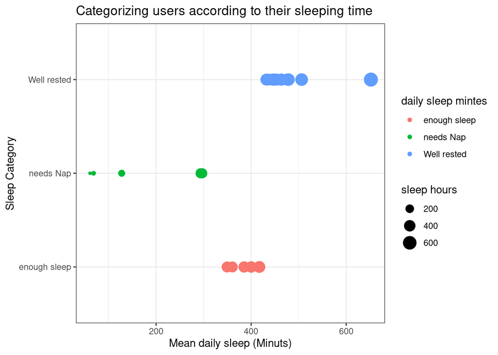

```r
View(user_type_2_sl)
user_type_2_sl %>%

  ggplot(data = user_type_2_sl, mapping = aes(x = mean_daily_sleep, y = user_type_2_sl,
                                             size = mean_daily_sleep, color = user_type_2_sl)) +
  geom_point() +
  theme_bw() +
  labs(x = "Mean daily sleep (Minuts)", y = "Sleep Category",
       color = "daily sleep mintes", size = "sleep hours") +

  ggtitle("Categorizing users according to their sleeping time")
```

### 5. 2 Users sleep behavior

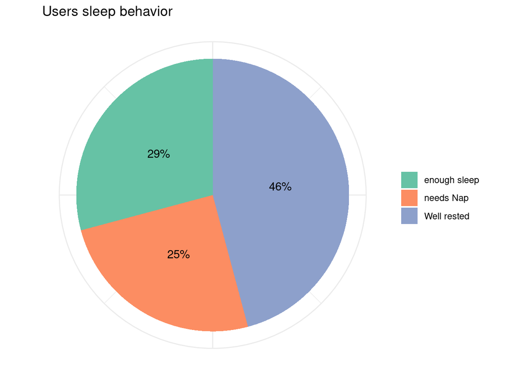

```r
user_data <- data.frame(
  user_type_2_sl = c(1, 2, 3),
  total_percent = c(0.25, 0.2916667, 0.4583333),
  labels = c("needs Nap", "enough sleep", "Well rested")
)
ggplot(user_data, aes(x = "", y = total_percent, fill = labels)) +
  geom_col(width = 1) +
  coord_polar(theta = "y") +
  labs(x = NULL, y = NULL, fill = NULL, title = "Users sleep behavior") +
  theme_minimal() +
  theme(axis.text = element_blank()) +
            geom_text(aes(label = paste0(round(total_percent * 100), "%")), position = position_stack(vjust = 0.5)) +
  scale_fill_brewer(palette = "Set2")
```

### 5. 3 Categorizing the users according to the level of calories expenditure

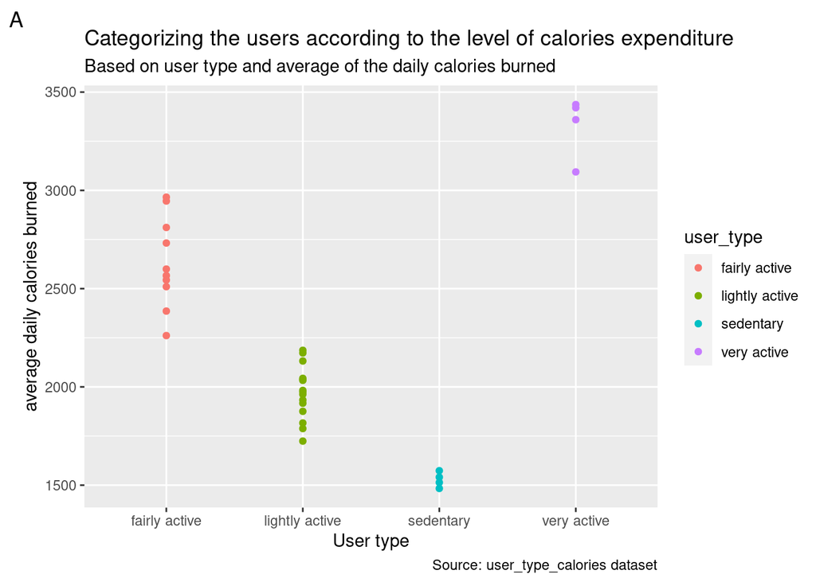

```r
user_type_calories %>%
 ggplot(data = user_type_calories, mapping = aes(x = user_type, y = mean_daily_calories, color = user_type)) +
 geom_point() +
 labs(title = "Categorizing the users according to the level of calories expenditure",
      subtitle = "Based on user type and average of the daily calories burned",
      x = "User type",
      y = "average daily calories burned",
      caption = "Source: user_type_calories dataset",
      tag = "A") +
  geom_smooth(method = "lm", formula = y ~ x, color = "red", size = 10, linetype = "dashed")
```

### 5. 4 Percentage of calories burnt by users

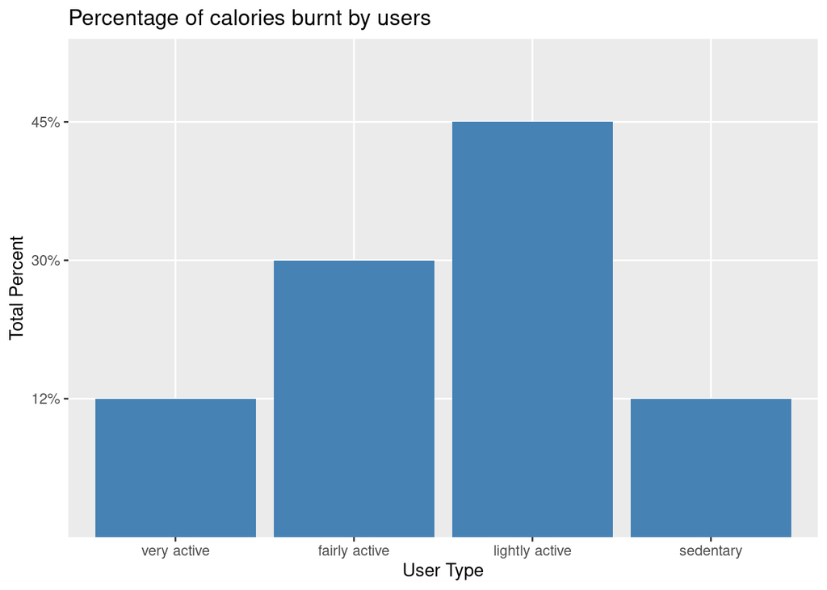

```r
user_type_percent_calories %>%
  ggplot(data = user_type_percent_calories, mapping = aes(x = user_type, y = labels)) +
  geom_bar(stat = "identity", fill = "steelblue") +
  labs(x = "User Type", y = "Total Percent", title = "Percentage of calories burnt by users")
```

### 5. 5 Histogram of mean daily calories burned per user

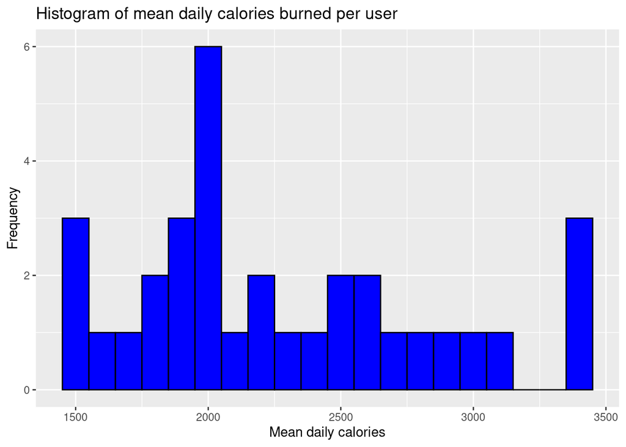

```r
Calories_average %>%
ggplot(data = Calories_average, mapping = aes(x = mean_daily_calories)) +
  geom_histogram(binwidth = 100, color = "black", fill = "blue") +
  labs(title = "Histogram of mean daily calories burned per user", x = "Mean daily calories", y = "Frequency")
```

### 5. 6 The correlation between activity and the amount of calories that users burn

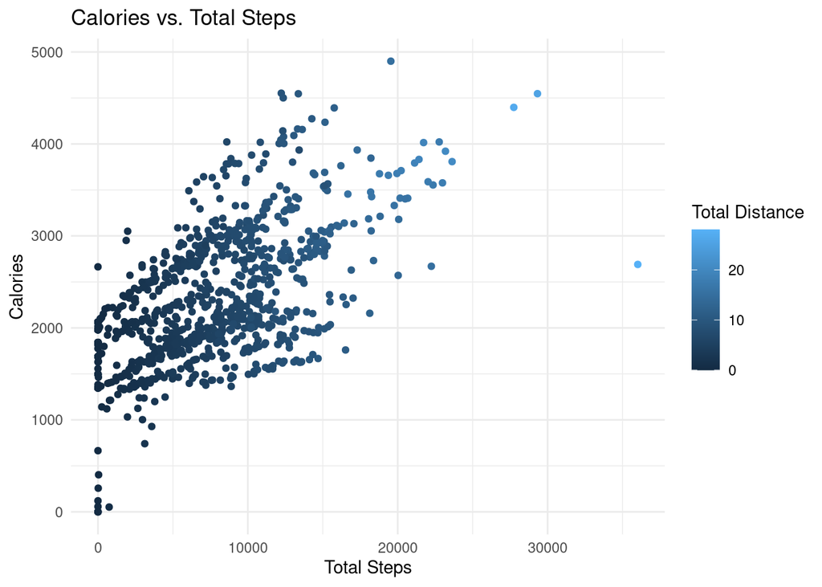

```r
dailyActivity_merged %>%
  ggplot(data = dailyActivity_merged, mapping = aes(x = TotalSteps, y = Calories, color = TotalDistance,)) +
  geom_point() +
  labs(title = "Calories vs. Total Steps", x = "Total Steps", y = "Calories", color = "Total Distance") +
  theme_minimal()
```

### 5. 7 A brief summary of the virtualization

During the visualization, we showcased the following data to support the Bellabeat team in visualizing the consumers’ behaviors.

A. We sorted the users into groups depending on how much they sleep and how many calories they burn, then visualized it to gather insights into how many people are using the app and how much is keeping them healthier.

B. We displayed the users’ sleep patterns as well as the correlation between activity level and calories burnt.

## 6. 0 Recommendations and insights

### 6. 2 Recommendations

- Those who are less active and sleep less should be reminded and given tips on how to improve their sleep and exercise levels.
- Add a notification feature to the app to assist users know when to sleep and when to exercise.
- Add a function in the app that allows consumers to set goals, and if they meet those goals, they should be rewarded with discounts and other perks, but not to the point where the company’s financial health is compromised.